# Data Cleaning with R

# Grouped Bar Plot

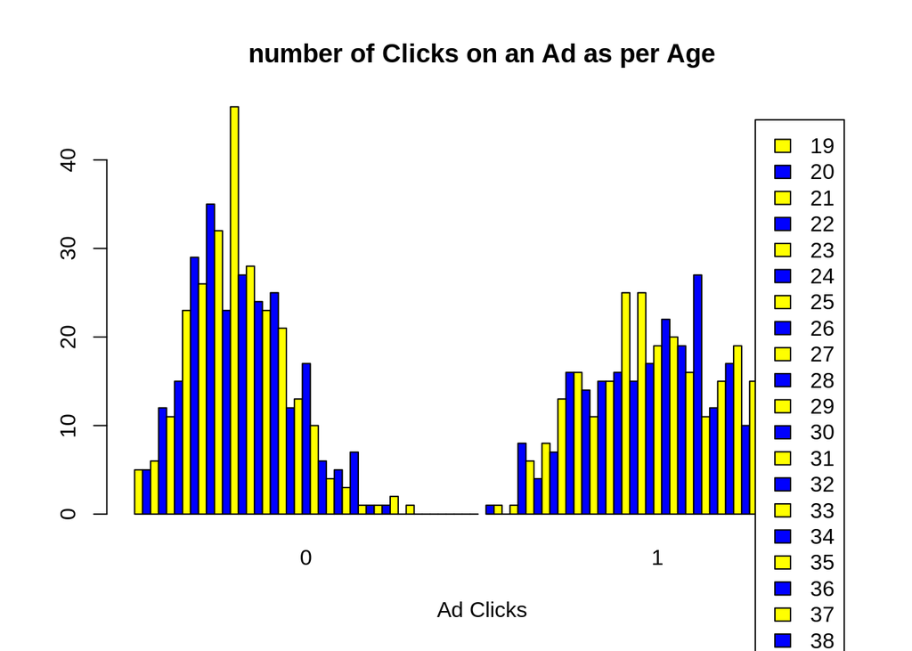

```r
counts = table(adverts$Age, adverts$Clicked.on.Ad)
barplot(counts, main="number of Clicks on an Ad as per Age",
xlab="Ad Clicks", col=c("yellow","blue"),
legend = rownames(counts), beside=TRUE)
```

## MULTIVARIATE ANALYSIS

> Getting the correlation matrix Visualizing the correlation matrix Variable reduction using the PCA approach.

###CORRELATION MATRIX We first select all the numeric variables from the dataframe Then from the variables, we find the correlation matrix

```r
adverts_2.cor <- cor(num_cols, method = c("spearman"))
adverts_2.cor
```

```
##                          Daily.Time.Spent.on.Site        Age Area.Income
## Daily.Time.Spent.on.Site                1.0000000 -0.3168616   0.2831344
## Age                                    -0.3168616  1.0000000  -0.1359540
## Area.Income                             0.2831344 -0.1359540   1.0000000
## Daily.Internet.Usage                    0.5141081 -0.3708639   0.3391602
##                          Daily.Internet.Usage
## Daily.Time.Spent.on.Site            0.5141081
## Age                                -0.3708639
## Area.Income                         0.3391602
## Daily.Internet.Usage                1.0000000
```

```r
install.packages("Hmisc")
```

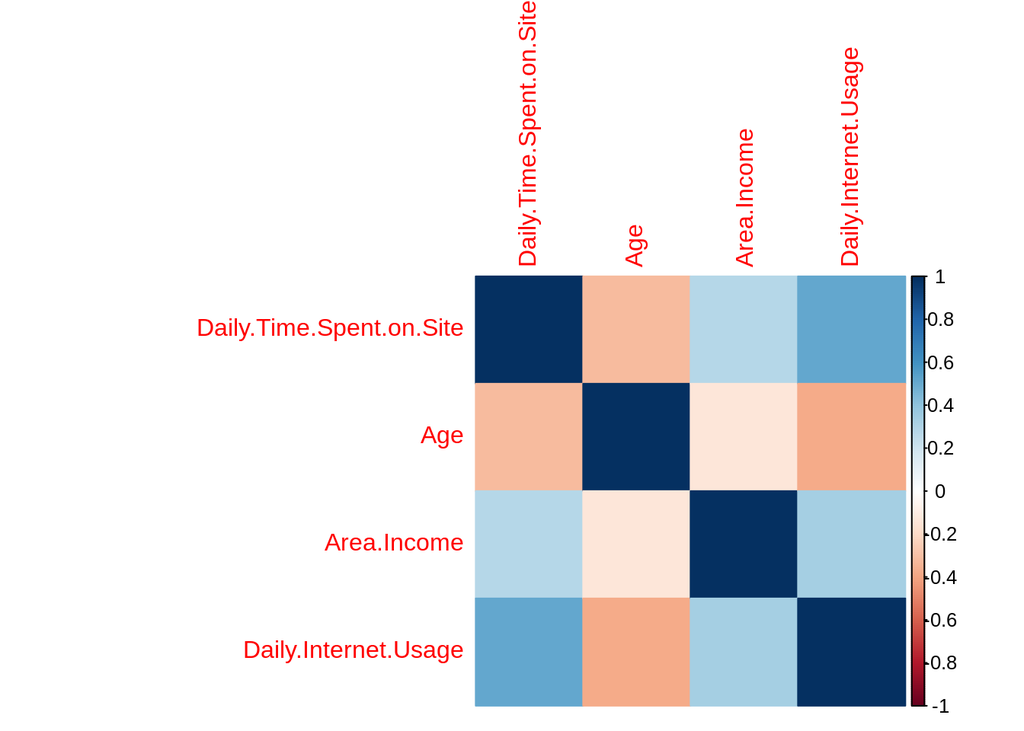

```r
install.packages("corrplot")
library("corrplot")
corrplot(adverts_2.cor, method="color")
```

### VARIABLE REDUCTION USING THE PRINCIPAL COMPONENT ANALYSIS

We really do not need to reduce the variables for this dataset as we are not going to go further with modelling. We shall however cover that as a way of introducing ourselves to PCA in R

```r
adverts.pca <- prcomp(num_cols, center = TRUE,scale. = TRUE)
adverts.pca
```

```
## Standard deviations (1, .., p=4):
## [1] 1.4301799 0.9047446 0.8114198 0.6911009
##
## Rotation (n x k) = (4 x 4):
##                                 PC1         PC2        PC3         PC4
## Daily.Time.Spent.on.Site -0.5484092  0.02789664 -0.5290308 -0.64698960
## Age                       0.4466724 -0.64437870 -0.6133591  0.09513391
## Area.Income              -0.4238013 -0.76334793  0.4827160 -0.06839365
## Daily.Internet.Usage     -0.5657947  0.03602522 -0.3330199  0.75344297
```